# Stats 155 Class Notes 2012-11-19

[Musical Theme for the Day](http://www.youtube.com/watch?v=G6djgavbp7c)

Question: What does 5 to 9 mean?

## Modeling of Categorical Variables

We're going to do the simplest case: two-level variables.

- This is an important case in practice since many problems have a substantial yes-no component, e.g. is the person living or dead.
- Problems with more levels can be reduced to a tree-like traversal of two-way decisions. An important technique — but far from the only one — is called CART.
- The prediction problem — given the inputs, what will be the output — is often called “classification”.
- But often we observe the results and want to figure out what theories account for them. In such cases, we need to look at model coefficients.

## Points to keep in mind as we study logistic regression

- Many of the same concepts and terminologies apply:
  - response and explanatory variables
  - model terms are just the same, including interaction and transformation terms
  - degrees of freedom works in much the same way
- Fitting is just as easy — let the computer do it.
- There's a regression report, standard errors, p-values on terms.
- There's something analogous to the ANOVA report, though we won't spend much time on it.
- But …
  - The fitted model values are not direct predictions of the outcome but probabilities.
  - Fitting is done in a different way
  - The moral equivalent of variance of the residuals is called deviance. There's also a summary of the quality of the fit with a lovely name: the “Akaike Information Criterion” (AIC). After “heteroskedascity”, this is my favorite statistics term.
  - The models are nonlinear in the parameters and interpretation is somewhat more difficult.

## Example:

Just so that you'll see that it's easy to do, let's do a simple model: Can we predict the sex of one of the kids from the width and length of the foot?

```r
mod = glm(sex ~ width + length, data = KidsFeet, family = "binomial")
summary(mod)
```

```
##
## Call:
## glm(formula = sex ~ width + length, family = "binomial", data = KidsFeet)
##
## Deviance Residuals:
##    Min      1Q  Median      3Q     Max
## -1.606  -1.030  -0.563   1.017   1.656
##
## Coefficients:
##             Estimate Std. Error z value Pr(>|z|)
## (Intercept)   18.139      8.155    2.22    0.026 *
## width         -1.649      0.967   -1.71    0.088 .
## length        -0.136      0.353   -0.39    0.699
## ---
## Signif. codes:  0 '***' 0.001 '**' 0.01 '*' 0.05 '.' 0.1 ' ' 1
##
## (Dispersion parameter for binomial family taken to be 1)
##
##     Null deviance: 54.040  on 38  degrees of freedom
## Residual deviance: 47.071  on 36  degrees of freedom
## AIC: 53.07
##
## Number of Fisher Scoring iterations: 4
```

```r
head(fitted(mod))  # probabilities
```

```
##      1      2      3      4      5      6
## 0.7246 0.5429 0.2334 0.1901 0.5120 0.2054
```

It's not obvious from the report whether these are the probability of being a girl or the probability of being a boy. Here's a plot to help out:

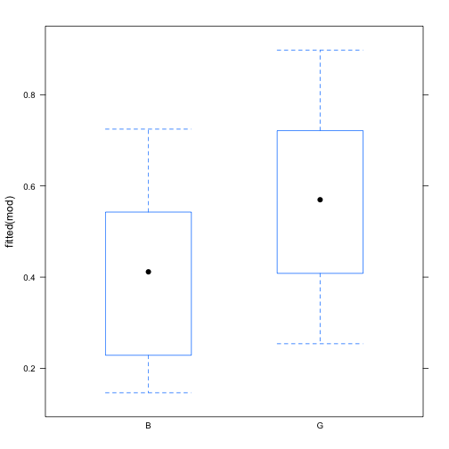

```r
bwplot(fitted(mod) ~ sex, data = KidsFeet)
```

It seems that the probability refers to being a girl, since the girls have a higher probability than the boys.

The functions themselves have a nice, graceful shape which you may recognize from Math 135 as being an S-function.

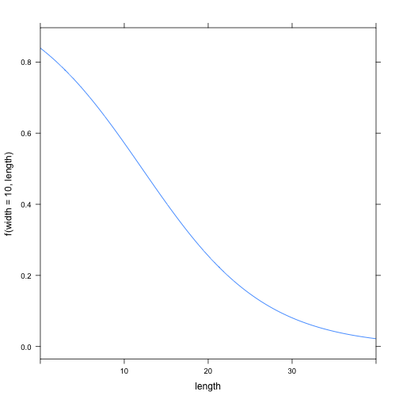

```r
f = makeFun(mod)
plotFun(f(width = 10, length) ~ length, length.lim = range(0, 40))
```

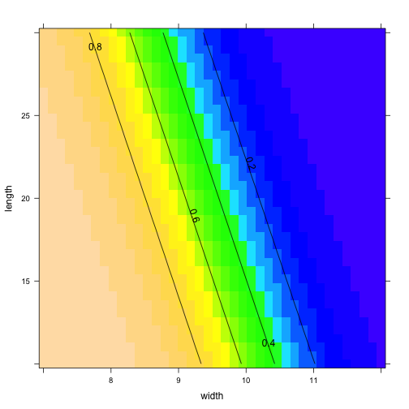

```r
plotFun(f(width = width, length = length) ~ width & length, length.lim = c(10,
    30), width.lim = c(7, 12))
```

ACTIVITY: Try adding in an interaction term, etc.

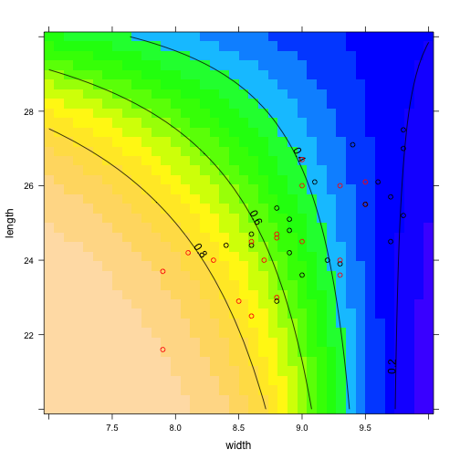

```r
mod2 = glm(sex ~ length * width, data = KidsFeet, family = "binomial")
f2 = makeFun(mod2)
plotFun(f2(width = width, length = length) ~ width & length, length.lim = c(20,
    30), width.lim = c(7, 10))
plotPoints(length ~ width, data = KidsFeet, add = TRUE, col = KidsFeet$sex)
```

## The Zero-One/TRUE-FALSE encoding

Look at the data in `oring-damage.csv`, which is about the space shuttle. The `damage` variable has been encoded as 0 or 1.

```r
oring = fetchData("oring-damage.csv")
```

```
## Retrieving from http://www.mosaic-web.org/go/datasets/oring-damage.csv
```

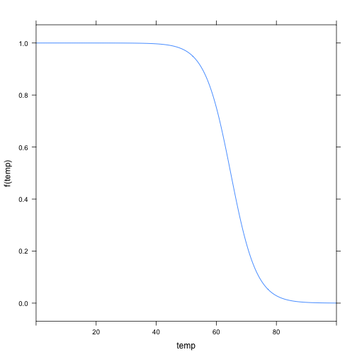

```r
mod = glm(damage ~ temp, data = oring, family = "binomial")
f = makeFun(mod)
plotFun(f(temp) ~ temp, temp.lim = range(0, 100))
```

Activity: Add in quadratic or cubic terms or stepwise terms and see how that changes the shape of the function. For instance:

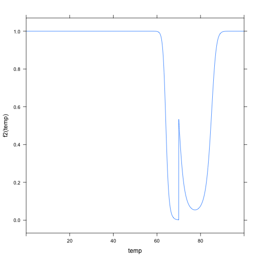

```r
mod2 = glm(damage ~ poly(temp, 2) + (temp < 70), data = oring, family = "binomial")
f2 = makeFun(mod2)
plotFun(f2(temp) ~ temp, temp.lim = range(0, 100))
```

The function doesn't need to be a simple step.

## Goals for this Unit

Since fitting and the report generation is trivial, and the report interpretation is superficially the same, we don't need to spend much time on that. Instead, we'll spend a bit of time on interpretation in a common setting: Case-Control studies.

We tend to think about three main kinds of studies:

- Experiment: You impose a treatment and see what happens. (We'll be talking about this the last week of the semester.)
- Cross-Sectional: Like your survey projects. Sample from a population.
- Cohort: You follow a group of people over time to see what develops.

But there is another kind of study that people don't usually think about but that can be very useful in certain circumstances.

There is a group that wants to do its survey about health outcomes for college students and the factors that determine them.